# Project: Investigate ford bike Dataset

- Introduction
- Data Wrangling
- Exploratory Data Analysis
- Conclusions

## Introduction

```python
import numpy as np
import pandas as pd
import matplotlib.pyplot as plt
import seaborn as sb
from datetime import datetime
%matplotlib inline

import warnings
warnings.simplefilter("ignore")
```

```python
ford_bike = pd.read_csv('201902-fordgobike-tripdata.csv')
```

## Data Wrangling

# assessment

```python
ford_bike.head()
```

|  | duration_sec | start_time | end_time | start_station_id | start_station_name | start_station_latitude | start_station_longitude | end_station_id | end_station_name | end_station_latitude | end_station_longitude | bike_id | user_type | member_birth_year | member_gender | bike_share_for_all_trip |
| --- | --- | --- | --- | --- | --- | --- | --- | --- | --- | --- | --- | --- | --- | --- | --- | --- |
| 0 | 52185 | 2019-02-28 17:32:10.1450 | 2019-03-01 08:01:55.9750 | 21.0 | Montgomery St BART Station (Market St at 2nd St) | 37.789625 | -122.400811 | 13.0 | Commercial St at Montgomery St | 37.794231 | -122.402923 | 4902 | Customer | 1984.0 | Male | No |
| 1 | 42521 | 2019-02-28 18:53:21.7890 | 2019-03-01 06:42:03.0560 | 23.0 | The Embarcadero at Steuart St | 37.791464 | -122.391034 | 81.0 | Berry St at 4th St | 37.775880 | -122.393170 | 2535 | Customer | NaN | NaN | No |
| 2 | 61854 | 2019-02-28 12:13:13.2180 | 2019-03-01 05:24:08.1460 | 86.0 | Market St at Dolores St | 37.769305 | -122.426826 | 3.0 | Powell St BART Station (Market St at 4th St) | 37.786375 | -122.404904 | 5905 | Customer | 1972.0 | Male | No |
| 3 | 36490 | 2019-02-28 17:54:26.0100 | 2019-03-01 04:02:36.8420 | 375.0 | Grove St at Masonic Ave | 37.774836 | -122.446546 | 70.0 | Central Ave at Fell St | 37.773311 | -122.444293 | 6638 | Subscriber | 1989.0 | Other | No |
| 4 | 1585 | 2019-02-28 23:54:18.5490 | 2019-03-01 00:20:44.0740 | 7.0 | Frank H Ogawa Plaza | 37.804562 | -122.271738 | 222.0 | 10th Ave at E 15th St | 37.792714 | -122.248780 | 4898 | Subscriber | 1974.0 | Male | Yes |

```python
ford_bike.info()
```

```
<class 'pandas.core.frame.DataFrame'>
RangeIndex: 183412 entries, 0 to 183411
Data columns (total 16 columns):
 #   Column                   Non-Null Count   Dtype
---  ------                   --------------   -----
 0   duration_sec             183412 non-null  int64
 1   start_time               183412 non-null  object
 2   end_time                 183412 non-null  object
 3   start_station_id         183215 non-null  float64
 4   start_station_name       183215 non-null  object
 5   start_station_latitude   183412 non-null  float64
 6   start_station_longitude  183412 non-null  float64
 7   end_station_id           183215 non-null  float64
 8   end_station_name         183215 non-null  object
 9   end_station_latitude     183412 non-null  float64
 10  end_station_longitude    183412 non-null  float64
 11  bike_id                  183412 non-null  int64
 12  user_type                183412 non-null  object
 13  member_birth_year        175147 non-null  float64
 14  member_gender            175147 non-null  object
 15  bike_share_for_all_trip  183412 non-null  object
dtypes: float64(7), int64(2), object(7)
memory usage: 22.4+ MB
```

```python
ford_bike.shape
```

```
(183412, 16)
```

```python
ford_bike.isnull().sum()
```

```
duration_sec                  0
start_time                    0
end_time                      0
start_station_id            197
start_station_name          197
start_station_latitude        0
start_station_longitude       0
end_station_id              197
end_station_name            197
end_station_latitude          0
end_station_longitude         0
bike_id                       0
user_type                     0
member_birth_year          8265
member_gender              8265
bike_share_for_all_trip       0
dtype: int64
```

```python
ford_bike['user_type'].unique()
```

```
array(['Customer', 'Subscriber'], dtype=object)
```

```python
ford_bike['member_gender'].unique()
```

```
array(['Male', nan, 'Other', 'Female'], dtype=object)
```

```python
ford_bike['bike_share_for_all_trip'].unique()
```

```
array(['No', 'Yes'], dtype=object)
```

```python
ford_bike.duplicated().value_counts()
```

```
False    183412
dtype: int64
```

### Data Cleaning

(1) removing null values

```python
ford_bike.dropna(inplace=True)
#checking
ford_bike.isnull().sum()
```

```
duration_sec               0
start_time                 0
end_time                   0
start_station_id           0
start_station_name         0
start_station_latitude     0
start_station_longitude    0
end_station_id             0
end_station_name           0
end_station_latitude       0
end_station_longitude      0
bike_id                    0
user_type                  0
member_birth_year          0
member_gender              0
bike_share_for_all_trip    0
dtype: int64
```

(2) removing unwanted columns

```python
ford_bike.drop(columns=['start_station_id', 'end_station_id','bike_id','start_station_latitude','start_station_longitude','end_station_latitude','end_station_longitude'], inplace=True)
#cheching
ford_bike.info()
```

```
<class 'pandas.core.frame.DataFrame'>
Int64Index: 174952 entries, 0 to 183411
Data columns (total 9 columns):
 #   Column                   Non-Null Count   Dtype
---  ------                   --------------   -----
 0   duration_sec             174952 non-null  int64
 1   start_time               174952 non-null  object
 2   end_time                 174952 non-null  object
 3   start_station_name       174952 non-null  object
 4   end_station_name         174952 non-null  object
 5   user_type                174952 non-null  object
 6   member_birth_year        174952 non-null  float64
 7   member_gender            174952 non-null  object
 8   bike_share_for_all_trip  174952 non-null  object
dtypes: float64(1), int64(1), object(7)
memory usage: 13.3+ MB
```

(3) fixing time format

```python
ford_bike.start_time = pd.to_datetime(ford_bike.start_time)
ford_bike.end_time = pd.to_datetime(ford_bike.end_time)
#checking
ford_bike.head()
```

|  | duration_sec | start_time | end_time | start_station_name | end_station_name | user_type | member_birth_year | member_gender | bike_share_for_all_trip |
| --- | --- | --- | --- | --- | --- | --- | --- | --- | --- |
| 0 | 52185 | 2019-02-28 17:32:10.145 | 2019-03-01 08:01:55.975 | Montgomery St BART Station (Market St at 2nd St) | Commercial St at Montgomery St | Customer | 1984.0 | Male | No |
| 2 | 61854 | 2019-02-28 12:13:13.218 | 2019-03-01 05:24:08.146 | Market St at Dolores St | Powell St BART Station (Market St at 4th St) | Customer | 1972.0 | Male | No |
| 3 | 36490 | 2019-02-28 17:54:26.010 | 2019-03-01 04:02:36.842 | Grove St at Masonic Ave | Central Ave at Fell St | Subscriber | 1989.0 | Other | No |
| 4 | 1585 | 2019-02-28 23:54:18.549 | 2019-03-01 00:20:44.074 | Frank H Ogawa Plaza | 10th Ave at E 15th St | Subscriber | 1974.0 | Male | Yes |
| 5 | 1793 | 2019-02-28 23:49:58.632 | 2019-03-01 00:19:51.760 | 4th St at Mission Bay Blvd S | Broadway at Kearny | Subscriber | 1959.0 | Male | No |

(3) splitting day, month and year from date

```python
ford_bike['year'] = ford_bike['start_time'].dt.year
ford_bike['month'] = ford_bike['start_time'].dt.month
ford_bike['day'] = ford_bike['start_time'].dt.day
ford_bike['hour'] = ford_bike['start_time'].dt.hour
#checking
ford_bike.head()
```

|  | duration_sec | start_time | end_time | start_station_name | end_station_name | user_type | member_birth_year | member_gender | bike_share_for_all_trip | year | month | day | hour |
| --- | --- | --- | --- | --- | --- | --- | --- | --- | --- | --- | --- | --- | --- |
| 0 | 52185 | 2019-02-28 17:32:10.145 | 2019-03-01 08:01:55.975 | Montgomery St BART Station (Market St at 2nd St) | Commercial St at Montgomery St | Customer | 1984.0 | Male | No | 2019 | 2 | 28 | 17 |
| 2 | 61854 | 2019-02-28 12:13:13.218 | 2019-03-01 05:24:08.146 | Market St at Dolores St | Powell St BART Station (Market St at 4th St) | Customer | 1972.0 | Male | No | 2019 | 2 | 28 | 12 |
| 3 | 36490 | 2019-02-28 17:54:26.010 | 2019-03-01 04:02:36.842 | Grove St at Masonic Ave | Central Ave at Fell St | Subscriber | 1989.0 | Other | No | 2019 | 2 | 28 | 17 |
| 4 | 1585 | 2019-02-28 23:54:18.549 | 2019-03-01 00:20:44.074 | Frank H Ogawa Plaza | 10th Ave at E 15th St | Subscriber | 1974.0 | Male | Yes | 2019 | 2 | 28 | 23 |
| 5 | 1793 | 2019-02-28 23:49:58.632 | 2019-03-01 00:19:51.760 | 4th St at Mission Bay Blvd S | Broadway at Kearny | Subscriber | 1959.0 | Male | No | 2019 | 2 | 28 | 23 |

(4) changing day and month into string

```python
ford_bike['day'] = ford_bike.start_time.dt.strftime('%a')
ford_bike['month'] = ford_bike.start_time.dt.strftime('%b')
ford_bike.head()
```

|  | duration_sec | start_time | end_time | start_station_name | end_station_name | user_type | member_birth_year | member_gender | bike_share_for_all_trip | year | month | day | hour |
| --- | --- | --- | --- | --- | --- | --- | --- | --- | --- | --- | --- | --- | --- |
| 0 | 52185 | 2019-02-28 17:32:10.145 | 2019-03-01 08:01:55.975 | Montgomery St BART Station (Market St at 2nd St) | Commercial St at Montgomery St | Customer | 1984.0 | Male | No | 2019 | Feb | Thu | 17 |
| 2 | 61854 | 2019-02-28 12:13:13.218 | 2019-03-01 05:24:08.146 | Market St at Dolores St | Powell St BART Station (Market St at 4th St) | Customer | 1972.0 | Male | No | 2019 | Feb | Thu | 12 |
| 3 | 36490 | 2019-02-28 17:54:26.010 | 2019-03-01 04:02:36.842 | Grove St at Masonic Ave | Central Ave at Fell St | Subscriber | 1989.0 | Other | No | 2019 | Feb | Thu | 17 |
| 4 | 1585 | 2019-02-28 23:54:18.549 | 2019-03-01 00:20:44.074 | Frank H Ogawa Plaza | 10th Ave at E 15th St | Subscriber | 1974.0 | Male | Yes | 2019 | Feb | Thu | 23 |
| 5 | 1793 | 2019-02-28 23:49:58.632 | 2019-03-01 00:19:51.760 | 4th St at Mission Bay Blvd S | Broadway at Kearny | Subscriber | 1959.0 | Male | No | 2019 | Feb | Thu | 23 |

(4) creating new columns for age

```python
ford_bike['age'] = datetime.now().year - ford_bike.member_birth_year
#checking
ford_bike.head()
```

|  | duration_sec | start_time | end_time | start_station_name | end_station_name | user_type | member_birth_year | member_gender | bike_share_for_all_trip | year | month | day | hour | age |
| --- | --- | --- | --- | --- | --- | --- | --- | --- | --- | --- | --- | --- | --- | --- |
| 0 | 52185 | 2019-02-28 17:32:10.145 | 2019-03-01 08:01:55.975 | Montgomery St BART Station (Market St at 2nd St) | Commercial St at Montgomery St | Customer | 1984.0 | Male | No | 2019 | Feb | Thu | 17 | 37.0 |
| 2 | 61854 | 2019-02-28 12:13:13.218 | 2019-03-01 05:24:08.146 | Market St at Dolores St | Powell St BART Station (Market St at 4th St) | Customer | 1972.0 | Male | No | 2019 | Feb | Thu | 12 | 49.0 |
| 3 | 36490 | 2019-02-28 17:54:26.010 | 2019-03-01 04:02:36.842 | Grove St at Masonic Ave | Central Ave at Fell St | Subscriber | 1989.0 | Other | No | 2019 | Feb | Thu | 17 | 32.0 |
| 4 | 1585 | 2019-02-28 23:54:18.549 | 2019-03-01 00:20:44.074 | Frank H Ogawa Plaza | 10th Ave at E 15th St | Subscriber | 1974.0 | Male | Yes | 2019 | Feb | Thu | 23 | 47.0 |
| 5 | 1793 | 2019-02-28 23:49:58.632 | 2019-03-01 00:19:51.760 | 4th St at Mission Bay Blvd S | Broadway at Kearny | Subscriber | 1959.0 | Male | No | 2019 | Feb | Thu | 23 | 62.0 |

(4) more refinning

```python
 ford_bike.drop(columns=['start_time', 'end_time','member_birth_year'], inplace=True)
```

(5)Reorder the days

```python
ford_bike['day'] = pd.Categorical(ford_bike['day'], categories=
    ['Mon','Tue','Wed','Thu','Fri','Sat', 'Sun'],
    ordered=True)
```

(6) converting age to int.

```python
ford_bike['age'] = ford_bike['age'].astype(int)
```

```python
bike_clean = ford_bike.copy()
display(bike_clean.dtypes)
```

```
duration_sec                  int64
start_station_name           object
end_station_name             object
user_type                    object
member_gender                object
bike_share_for_all_trip      object
year                          int64
month                        object
day                        category
hour                          int64
age                           int32
dtype: object
```

## Exploratory Data Analysis

# first let's make quick statistics for the data

```python
bike_clean.describe()
```

|  | duration_sec | year | hour | age |
| --- | --- | --- | --- | --- |
| count | 174952.000000 | 174952.0 | 174952.000000 | 174952.000000 |
| mean | 704.002744 | 2019.0 | 13.456165 | 36.196865 |
| std | 1642.204905 | 0.0 | 4.734282 | 10.118731 |
| min | 61.000000 | 2019.0 | 0.000000 | 20.000000 |
| 25% | 323.000000 | 2019.0 | 9.000000 | 29.000000 |
| 50% | 510.000000 | 2019.0 | 14.000000 | 34.000000 |
| 75% | 789.000000 | 2019.0 | 17.000000 | 41.000000 |
| max | 84548.000000 | 2019.0 | 23.000000 | 143.000000 |

# Univariate Exploration

### (1) what is the most frequent start point?

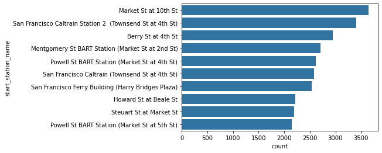

```python
freq_start = bike_clean['start_station_name'].value_counts()[:10]
start_station_order = freq_start.index
sb.countplot(data=bike_clean, y='start_station_name', color=sb.color_palette()[0], order=start_station_order);
```

# MARKET ST. AT 10TH ST.

### is the most popular start point

### (2) what is the most frequent end point?

[figure not shown]

```python
freq_end = bike_clean['end_station_name'].value_counts()[:10]
end_station_order = freq_end.index
sb.countplot(data=bike_clean, y='end_station_name', color=sb.color_palette()[0], order=end_station_order);
```

# SAN FRANCISCO CALTRAIN STAION 2

### is the popular end point

### (3) what is the average age for bike riders?

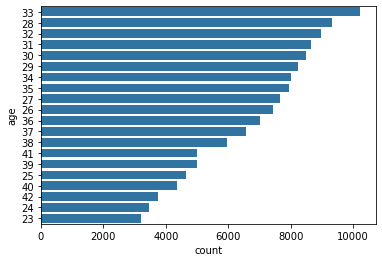

```python
freq_age = bike_clean['age'].value_counts()[:20]
age_order = freq_age.index
sb.countplot(data=bike_clean, y='age', color=sb.color_palette()[0], order=age_order);
```

# people with age 33 are common bike riders

people with with age range(25-42) are more likely to use bikes

people(<25) and (>42) not fammiler wih bike riding

```python
bike_clean.age.describe()
```

```
count    174952.000000
mean         36.196865
std          10.118731
min          20.000000
25%          29.000000
50%          34.000000
75%          41.000000
max         143.000000
Name: age, dtype: float64
```

### (4)what is the day with higher rides?

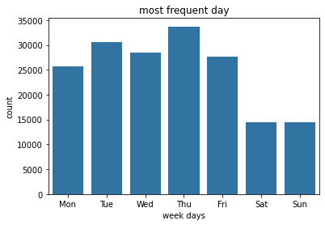

```python
sb.countplot(data=bike_clean, x='day', color=sb.color_palette()[0]);
plt.xlabel('week days')
plt.title('most frequent day');
```

# THURSDAY has the higher rides no.

### (5)what is the gender tends to use bikes?

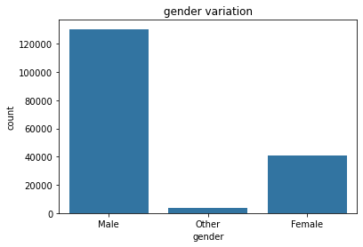

```python
sb.countplot(data=bike_clean, x='member_gender', color=sb.color_palette()[0]);
plt.xlabel('gender')
plt.title('gender variation');
```

# MALE tends to use bikes

### (6) what is the loyality of the bikers?

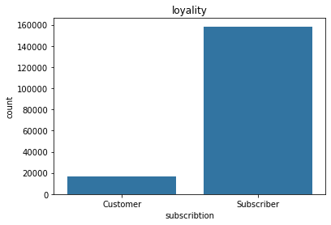

```python
sb.countplot(data=bike_clean, x='user_type', color=sb.color_palette()[0]);
plt.xlabel('subscribtion')
plt.title('loyality');
```

# the highest no. of bikers use the service regulary

# Bivariate visualizations

# (1)what is the rush hours?

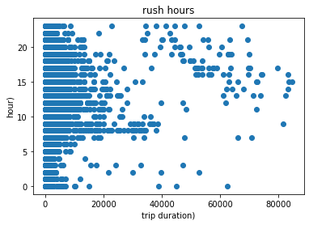

```python
plt.scatter(data = bike_clean, x = 'duration_sec', y = 'hour');
plt.xlabel('trip duration)')
plt.ylabel('hour)')
plt.title('rush hours');
```

# trip duration increases in rush hours

## (2)what is the relation between trip duration and age?

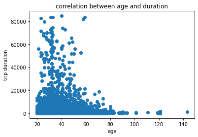

```python
plt.scatter(data = bike_clean, x = 'age', y = 'duration_sec');
plt.xlabel('age')
plt.ylabel('trip duration')
plt.title('correlation between age and duration');
```

# as expected the youngest bikers more likely to ride for long time

## (3) what is the relation between age and gender?

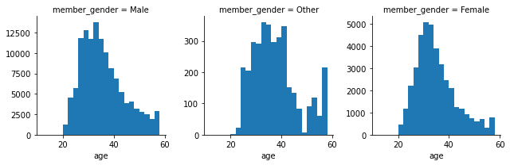

```python
bin_edges = np.arange(12, 58+2, 2)
g = sb.FacetGrid(data = bike_clean, col = 'member_gender', col_wrap=3, sharey=False)
g.map(plt.hist, 'age', bins = bin_edges);
```

# men age (>50) tend to use bikes more than women in the same age

# (4) does the time affect user type?

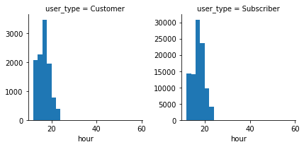

```python
bin_edges = np.arange(12, 58+2, 2)
g = sb.FacetGrid(data = bike_clean, col = 'user_type', col_wrap=3, sharey=False)
g.map(plt.hist, 'hour', bins = bin_edges);
```

# rush hours doesn't affect user type

### (5) which time is more likely for men and women?

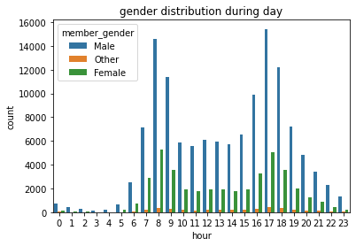

```python
sb.countplot(data=bike_clean, x='hour', hue='member_gender')
plt.title('gender distribution during day');
```

# as expected men and women usage peak still the same during day

# Multivariate exploration

### (1) what is the relation between duration ,age and hour?

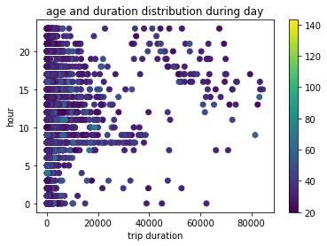

```python
plt.scatter(data = bike_clean, x = 'duration_sec', y = 'hour', c = 'age')
plt.colorbar()
plt.xlabel('trip duration')
plt.ylabel('hour')
plt.title('age and duration distribution during day');
```